# Empreendedorismo Corporativo, Intraempreendedorismo e Spin-offs

Empreendedorismo Tecnológico e Desenvolvimento Territorial · Aula 11

Prof. Dr. Luiz Diego Vidal Santos

## Unidade II Visão Geral da Aula

**01 · Conceitos:** Intraempreendedorismo vs. Empreendedorismo Corporativo.

**02 · Inovação Aberta:** *Open Innovation* (Chesbrough, 2003).

**03 · Capital Corporativo:** *Corporate Venture Capital* (CVC) e interação com *startups* locais.

**04 · Desdobramentos:** *Spin-offs* corporativas e acadêmicas no território.

**05 · Setor Público e Cooperativo:** Intraempreendedorismo no Estado e em cooperativas.

Objetivo da Aula Renovar capacidades a partir de dentro

Analisar como organizações estabelecidas (empresas, cooperativas, universidades e órgãos públicos) renovam suas capacidades por meio do **intraempreendedorismo**, da **inovação aberta** e da criação de *spin-offs* enraizadas no território.

Intraempreendedorismo Inovação Aberta Spin-offs

## Unidade II Ponto de Partida: Inovar Sem Começar do Zero

01 · Organizações Existentes Além da Startup de Garagem

- Nem toda inovação nasce fora das instituições: empresas estabelecidas, cooperativas agrícolas, universidades e prefeituras concentram conhecimento, infraestrutura e rede de clientes.
- Quando colaboradores criam novas soluções dentro dessas estruturas, temos o **intraempreendedorismo**.

02 · Novos Negócios Derivados Quando a Ideia Ganha Vida Própria

- Muitas vezes uma pesquisa universitária ou um projeto interno precisa de agilidade própria para chegar ao mercado.
- Surge então uma *spin-off*: uma nova empresa que nasce a partir do conhecimento gerado dentro de uma organização-mãe, retendo talentos e tecnologia no território.

Organizações-mãe ancoram competências acumuladas; *spin-offs* e programas internos convertem esse estoque de conhecimento em dinamismo produtivo territorial.

# Empreendedorismo em Organizações Existentes

## Corporativo Conceitos e Dimensões (Pinchot, 1985; Guth & Ginsberg, 1990)

Tipologia e Dimensões Distinções Fundamentais

- **Intraempreendedorismo:** iniciativa de colaboradores dentro da organização para desenvolver novos produtos, processos ou unidades de negócio usando recursos internos.
- **Empreendedorismo Corporativo (*Corporate Entrepreneurship*):** estratégia institucionalizada da firma envolvendo:
  1. **Renovação estratégica** (redefinição do negócio central);
  2. **Inovação sustentada** (novos produtos/serviços);
  3. *Corporate Venturing* (criação ou investimento em novos negócios).

Obstáculos e Ambidestria Barreiras Internas à Inovação

- Aversão ao risco e foco exclusivo em métricas de curto prazo (*core business* atual).
- Silos departamentais e falta de autonomia decisória.
- **Solução organizacional:** *ambidestria organizacional* (O’Reilly & Tushman) — equilibrar a **exploração eficiente** (*exploitation*) do negócio atual com a **busca experimental** (*exploration*) do futuro.

Programas de *Corporate Venture Capital* (CVC) ampliam essa ambidestria ao investir e co-desenvolver soluções diretamente com *startups* locais.

# Inovação Aberta e Spin-offs

## Território *Open Innovation* e *Spin-offs* Acadêmicas

Chesbrough (2003) Paradigma Aberto

- **Modelo Fechado:** P&D 100% interno, segredo absoluto, comercialização apenas pela própria firma.
- **Modelo Aberto:** fluxos intencionais de entrada (*inbound*) e saída (*outbound*) de conhecimento, envolvendo *startups*, universidades, fornecedores e clientes.
- **Conexão Territorial:** grandes empresas âncoras instaladas em um território (ex.: polos industriais, agroindústrias, energia) podem atuar como **tratores de inovação** para *startups* locais via programas de inovação aberta.

ICTs e NITs *Spin-offs* Acadêmicas e Transferência de Tecnologia

- **Definição:** novas empresas criadas para explorar comercialmente resultados de pesquisa científica gerados em universidades ou ICTs.
- **Desafios no Brasil:** transição do pesquisador para o papel empreendedor, licenciamento de propriedade intelectual pelos NITs e acesso a capital de risco para escala.

## Método Trajetória da Inovação Aberta às *Spin-offs* Acadêmicas

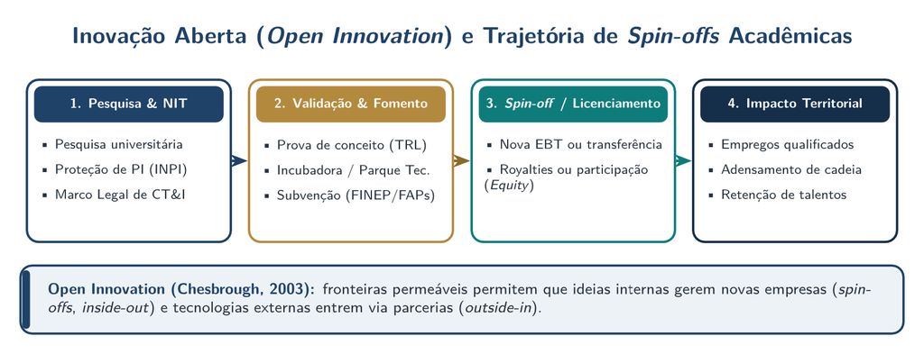

Fluxo da inovação aberta e spin-offs acadêmicas da pesquisa ao impacto territorial.

Fluxo da inovação aberta e *spin-offs* acadêmicas Da geração de conhecimento em ICTs e empresas âncoras ao impacto produtivo territorial

NITs, CVC e programas de inovação aberta conectam a fronteira científica à demanda produtiva local sem exigir que a firma inove isoladamente.

# Setor Público e Fechamento da Unidade II

## Síntese Intraempreendedorismo Público e Leituras

Estado e Cooperativas Inovação no Setor Público Territorial

- Laboratórios de inovação governamental (*GovTechs* e *Living Labs* municipais).
- Uso de compras públicas de inovação e sandboxes regulatórios para testar soluções urbanas, ambientais e de defesa civil.
- Fortalecimento de cooperativas e arranjos produtivos por meio de equipes internas de inovação.

Próxima Aula · Unidade III Leituras Recomendadas

- **WOILER, S.; MATHIAS, W. F.** *Projetos: planejamento, elaboração e análise* (Caps. 1 a 4 — Mercado, Tamanho e Localização).
- **CASAROTTO FILHO, N.; KOPITTKE, B. H.** *Análise de investimentos* (Caps. introdutórios sobre elaboração de projetos).